# AMES Housing Data - EDA

Import packages and the dataset.

```r
library(ggplot2)
library(epiDisplay)
library(dplyr)
library(visdat)
library(corrplot)
options(scipen=10000)
```

Import the dataset.

```r
df <- data.frame(AMES_TRAIN)
head(df)
```

|  | SubClass | Zoning | LotFrontage | LotArea | Street | Alley | LotShape | LandContour | Utilities | LotConfig | LandSlope | Neighborhood | Condition1 | Condition2 | BldgType | HouseStyle | OverallQual | OverallCond | YearBuilt | YearRemodel | RoofStyle | RoofMat | Exterior1 | Exterior2 | MasVnrType | MasVnrArea | ExterQual | ExterCond | Foundation | … |
| --- | --- | --- | --- | --- | --- | --- | --- | --- | --- | --- | --- | --- | --- | --- | --- | --- | --- | --- | --- | --- | --- | --- | --- | --- | --- | --- | --- | --- | --- | --- |
| 1 | 20 | RL | NA | 11838 | Pave | NA | Reg | Lvl | AllPub | Inside | Gtl | CollgCr | Norm | Norm | 1Fam | 1Story | 8 | 5 | 2001 | 2001 | Hip | CompShg | VinylSd | VinylSd | None | 0 | Gd | TA | PConc | … |
| 2 | 60 | RL | 70 | 8304 | Pave | NA | IR1 | Lvl | AllPub | Inside | Gtl | SawyerW | Norm | Norm | 1Fam | 2Story | 6 | 5 | 1997 | 1998 | Gable | CompShg | VinylSd | VinylSd | None | 0 | TA | TA | PConc | … |
| 3 | 45 | RM | 58 | 6380 | Pave | NA | Reg | Lvl | AllPub | Inside | Gtl | BrkSide | Norm | Norm | 1Fam | 1.5Unf | 5 | 6 | 1922 | 1950 | Gable | CompShg | MetalSd | MetalSd | None | 0 | TA | TA | BrkTil | … |
| 4 | 60 | RL | NA | 14803 | Pave | NA | IR1 | Lvl | AllPub | CulDSac | Gtl | NWAmes | Norm | Norm | 1Fam | 2Story | 6 | 5 | 1971 | 1971 | Gable | CompShg | HdBoard | HdBoard | BrkFace | 252 | TA | TA | CBlock | … |
| 5 | 20 | RL | 91 | 11375 | Pave | NA | Reg | Lvl | AllPub | Inside | Gtl | Sawyer | Norm | Norm | 1Fam | 1Story | 6 | 5 | 1954 | 1995 | Gable | CompShg | VinylSd | VinylSd | None | 0 | TA | TA | CBlock | … |
| 6 | 30 | RL | 55 | 7111 | Pave | NA | IR1 | Bnk | AllPub | Inside | Gtl | BrkSide | Norm | Norm | 1Fam | 1Story | 5 | 7 | 1928 | 1983 | Gable | CompShg | WdShing | Wd Shng | None | 0 | Gd | Gd | BrkTil | … |

# Define the sample

1. Select the variables of interest.

```r
df <- df %>%
  select(Zoning, LotFrontage, LotArea, BldgType, OverallQual, OverallCond, YearBuilt, YearRemodel, ExterQual, FirstFlrSF, SecondFlrSF, FullBath, HalfBath, BsmtFullBath, BsmtHalfBath, BedroomAbvGr, KitchenQual, GarageArea, SaleCondition, SalePrice, index)

df
```

| Zoning | LotFrontage | LotArea | BldgType | OverallQual | OverallCond | YearBuilt | YearRemodel | ExterQual | FirstFlrSF | SecondFlrSF | FullBath | HalfBath | BsmtFullBath | BsmtHalfBath | BedroomAbvGr | KitchenQual | GarageArea | SaleCondition | SalePrice | index |
| --- | --- | --- | --- | --- | --- | --- | --- | --- | --- | --- | --- | --- | --- | --- | --- | --- | --- | --- | --- | --- |
| RL | NA | 11838 | 1Fam | 8 | 5 | 2001 | 2001 | Gd | 1788 | 0 | 2 | 0 | 0 | 0 | 3 | Ex | 522 | Normal | 236500 | 2 |
| RL | 70 | 8304 | 1Fam | 6 | 5 | 1997 | 1998 | TA | 941 | 896 | 2 | 1 | 0 | 0 | 3 | TA | 688 | Normal | 187000 | 3 |
| RM | 58 | 6380 | 1Fam | 5 | 6 | 1922 | 1950 | TA | 1048 | 0 | 1 | 0 | 0 | 0 | 2 | TA | 280 | Normal | 113000 | 5 |
| RL | NA | 14803 | 1Fam | 6 | 5 | 1971 | 1971 | TA | 1097 | 896 | 2 | 1 | 0 | 0 | 4 | TA | 495 | Normal | 190000 | 6 |
| RL | 91 | 11375 | 1Fam | 6 | 5 | 1954 | 1995 | TA | 1299 | 0 | 1 | 0 | 0 | 0 | 3 | Gd | 494 | Normal | 150000 | 8 |
| RL | 55 | 7111 | 1Fam | 5 | 7 | 1928 | 1983 | Gd | 1143 | 0 | 1 | 0 | 0 | 0 | 2 | TA | 288 | Normal | 138000 | 9 |
| RM | 60 | 11340 | 1Fam | 2 | 1 | 1920 | 1950 | Fa | 723 | 363 | 1 | 0 | 0 | 0 | 2 | TA | 400 | Normal | 55000 | 10 |
| RL | 53 | 4043 | TwnhsE | 6 | 6 | 1977 | 1977 | TA | 1069 | 0 | 2 | 0 | 0 | 0 | 2 | TA | 440 | Abnorml | 140000 | 12 |
| FV | 84 | 10728 | 1Fam | 8 | 5 | 2006 | 2006 | Gd | 1095 | 844 | 2 | 1 | 0 | 0 | 3 | Gd | 1053 | Partial | 266000 | 14 |
| RL | 24 | 2308 | TwnhsE | 6 | 5 | 1974 | 1974 | TA | 855 | 467 | 2 | 1 | 0 | 1 | 3 | TA | 440 | Normal | 147000 | 16 |

[output cut: 990 more lines]

2. let’s look at how many records are missing values in our dataset.

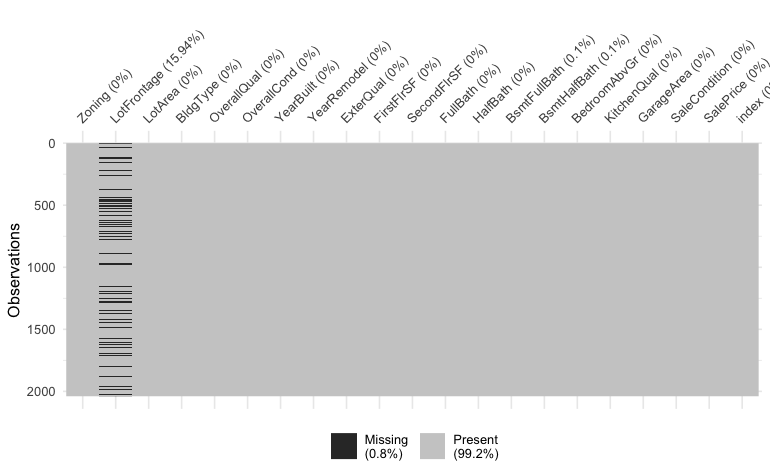

```r
vis_miss(df)
```

3. Subset only properties that are Residential

```r
df <- subset(df, df$Zoning == 'RH' | df$Zoning == 'RL' | df$Zoning == 'RP' | df$Zoning == 'RM')
```

4. Subset only properties that had normal sale conditions.

```r
df <- subset(df, df$SaleCondition == 'Normal')
```

5. Examine BldgType with a frequency table and histogram.

```
df$BldgType :
        Frequency Percent Cum. percent
1Fam         1369    85.6         85.6
TwnhsE        100     6.2         91.8
Twnhs          52     3.2         95.1
Duplex         52     3.2         98.3
2fmCon         27     1.7        100.0
  Total      1600   100.0        100.0
```

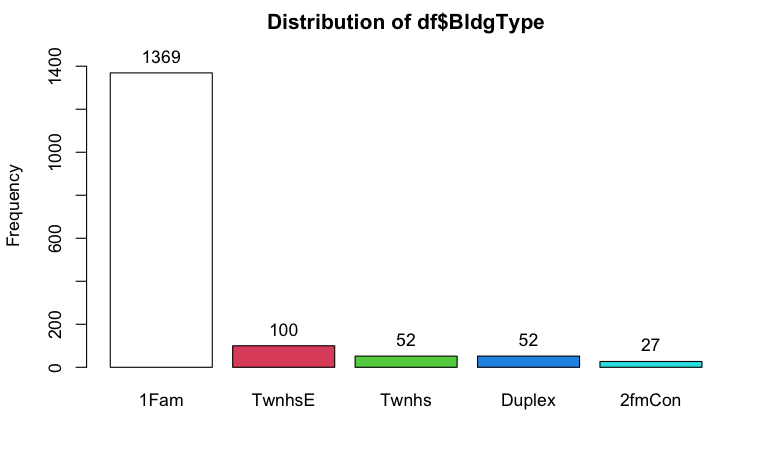

```r
tab1(df$BldgType, sort.group = "decreasing", cum.percent = TRUE)
```

**Keep only records that are BldgType = 1Fam.**

```r
df <- df %>% filter(BldgType == "1Fam" | is.na(BldgType))
```

6. Examine SalePrice and remove outliers.

```r
summary(df$SalePrice)
```

```
   Min. 1st Qu.  Median    Mean 3rd Qu.    Max.
  45000  129000  159000  176514  205000  625000
```

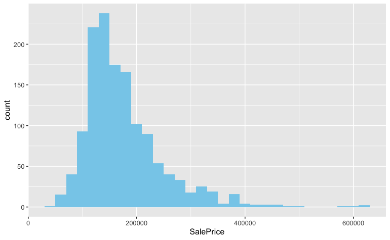

```r
ggplot(df, aes(x=SalePrice)) + geom_histogram(fill='sky blue')
```

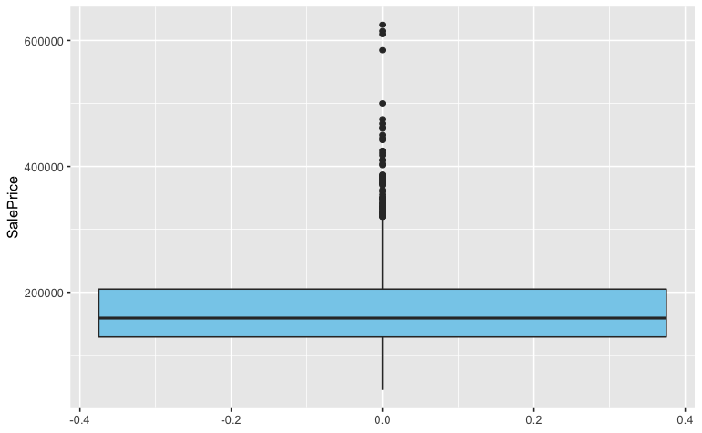

```r
ggplot(df, aes(y=SalePrice)) + geom_boxplot(fill='sky blue')
```

ggplot2 boxplots define outliers above the median as values greater than Q3 + 1.5*IQR. [source - stackoverflow](https://stackoverflow.com/questions/4946964/in-ggplot2-what-do-the-end-of-the-boxplot-lines-represent)